# SLP Estimations: Data Analysis

This is the analysis script for the manuscript entitled “The reliability and validity of SLPs’ estimations of speech intelligibility in dysarthria”. Much of the analysis and code is the same from the 2021 ASHA Convention poster presentation. However, some of the data visualizations and tables have changed.

# Packages

```r
library(rio) # install.packages("rio")
library(tidyverse) # install.packages("tidyverse")
library(performance) # install.packages("performance")
library(see) # install.packages("see")
library(rmcorr) #install.packages("rmcorr")
library(irr) #install.packages("irr")
library(Hmisc) #install.packages("Hmisc")
library(extrafont) # install.packages("extrafont")
library(gt) #install.packages("gt")
library(sjPlot) #install.packages("sjPlot")
```

# Importing the datasets

This chunk contains all of the dataframes needed for the statistical analysis.

```r
# This data is used for question #1 & 2
slp_Demographics <- rio::import("Shared Data/SLP_Demographics.csv")
slp_Correlation <- rio::import("Shared Data/SLP_Correlation.csv")

# This data is used for question #3
IntSpeakerRatings <- rio::import("Shared Data/SpeakerIntelligibility.csv")

# Naïve Listener Data
naive_Demographics <- rio::import("Shared Data/NaiveListener_Demographics.csv")
naive_Correlation <- rio::import("Shared Data/NaiveListener_Correlation.csv")
```

# Descriptive Statistics

## SLP Demographics

```r
#creating separate data frames for SLP gender, race, and ethnicity demographic information

slp_gender <- slp_Demographics %>%
  dplyr::select(gender) %>%
  dplyr::group_by(gender) %>%
  dplyr::summarize(Frequency = n()) %>%
  dplyr::rename(Category = "gender") %>%
  dplyr::mutate(Group = "Gender",
                Category = fct_relevel(Category, c("Woman", "Man", "Prefer not to say"))) %>%
  dplyr::arrange(Category)

slp_race <- slp_Demographics %>%
  dplyr::select(race) %>%
  dplyr::group_by(race) %>%
  dplyr::summarize(Frequency = n()) %>%
  dplyr::rename(Category = "race") %>%
  dplyr::mutate(Group = "Race")

slp_ethnicity <- slp_Demographics %>%
  dplyr::select(ethnicity) %>%
  dplyr::group_by(ethnicity) %>%
  dplyr::summarize(Frequency = n()) %>%
  dplyr::rename(Category = "ethnicity") %>%
  dplyr::mutate(Group = "Ethnicity")

#merging these separate data frames together

slp_demo1 <- dplyr::full_join(slp_gender, slp_race)
slp_demo1 <- dplyr::full_join(slp_demo1, slp_ethnicity)
#creating the SLP demographic tables

## Race, gender, and ethicity information

slp_demo_table1 <- slp_demo1 %>%
  gt::gt(rowname_col = "Category", groupname_col = "Group")

slp_demo_table1
```

|  | Frequency |
| --- | --- |
| Gender |  |
| Woman | 17 |
| Man | 3 |
| Prefer not to say | 1 |
| Race |  |
| Asian American | 1 |
| White/Caucasian | 20 |
| Ethnicity |  |
| Not Hispanic/Latino | 21 |

```r
## saving table to folder

slp_demo_table1 %>% gt::gtsave("Tables/SLP_demo1.html")

## SLP Age and Years experience information

slp_demo_table2 <- slp_Demographics %>%
  dplyr::select(c(age, yearsExp)) %>%
  tidyr::pivot_longer(cols = c(age, yearsExp), names_to = "Variable", values_to = "Value") %>%
  dplyr::mutate(Variable = recode(Variable, age = "Age", yearsExp = "Years Experience")) %>%
  dplyr::group_by(Variable) %>%
  dplyr::summarize(Mean = mean(Value), SD = sd(Value), Min = min(Value), Max = max(Value)) %>%
  gt::gt() %>%
  gt::fmt_number(columns = c(Mean, SD), decimals = 2)

slp_demo_table2
```

| Variable | Mean | SD | Min | Max |
| --- | --- | --- | --- | --- |
| Age | 33.81 | 10.15 | 24 | 67 |
| Years Experience | 8.69 | 9.62 | 1 | 41 |

```r
## saving table to folder

slp_demo_table2 %>% gt::gtsave("Tables/SLP_demo2.html")

# removing extra items from the environment that are no longer needed

rm(slp_gender, slp_race, slp_ethnicity, slp_demo1)
```

## Naive Listener Demographics

```r
#creating separate data frames for naive listener gender, race, ethnicity, and familiarity with speech language and hearing disorders (famSLHDs) information

naive_gender <- naive_Demographics %>%
  dplyr::select(gender) %>%
  dplyr::group_by(gender) %>%
  dplyr::summarize(Frequency = n()) %>%
  dplyr::rename(Category = "gender") %>%
  dplyr::mutate(Group = "Gender",
                Category = fct_relevel(Category, c("Woman", "Man", "Prefer not to say"))) %>%
  dplyr::arrange(Category)
```

```
Unknown levels in `f`: Prefer not to say
```

```r
naive_race <- naive_Demographics %>%
  dplyr::select(race) %>%
  dplyr::group_by(race) %>%
  dplyr::summarize(Frequency = n()) %>%
  dplyr::rename(Category = "race") %>%
  dplyr::mutate(Group = "Race")

naive_ethnicity <- naive_Demographics %>%
  dplyr::select(ethnicity) %>%
  dplyr::group_by(ethnicity) %>%
  dplyr::summarize(Frequency = n()) %>%
  dplyr::rename(Category = "ethnicity") %>%
  dplyr::mutate(Group = "Ethnicity")

naive_famSLHDs <- naive_Demographics %>%
  dplyr::select(famSLHDs) %>%
  dplyr::group_by(famSLHDs) %>%
  dplyr::summarize(Frequency = n()) %>%
  dplyr::rename(Category = "famSLHDs") %>%
  dplyr::mutate(Group = "Familiar with Comm Disorders")

# Merging these separate data frames together

naive_demo1 <- dplyr::full_join(naive_gender, naive_race)
naive_demo2 <- dplyr::full_join(naive_demo1, naive_ethnicity)
naive_demo3 <- dplyr::full_join(naive_demo2, naive_famSLHDs)
#creating demographic table

naive_demo_table <- naive_demo3 %>%
  gt::gt(rowname_col = "Category", groupname_col = "Group")

#saving table to folder

naive_demo_table %>% gt::gtsave("Tables/Naive_demo.html")

#calculating demographic age information for naive listeners (not saved to tables folder, but reported in manuscript)

naive_Demographics %>%
  dplyr::summarize(Age_mean = mean(age), Age_sd = sd(age), Age_min = min(age), Age_max = max(age))
```

| Age_mean | Age_sd | Age_min | Age_max |
| --- | --- | --- | --- |
| 34.8 | 13.94253 | 19 | 74 |

```r
# removing extra items from the environment that are no longer needed

rm(naive_gender, naive_race, naive_ethnicity, naive_famSLHDs, naive_demo1, naive_demo2, naive_demo3)
```

## SLP and Naive Listener Descriptive Measures across Speakers

```r
#creating descriptives data frame

IntSpeakerRatings1 <- IntSpeakerRatings %>%
  dplyr::select(!naive_VAS) %>%
  dplyr::mutate(Etiology = case_when(
    grepl("ALS", SpeakerID, fixed = T) ~ "ALS",
    grepl("PD", SpeakerID, fixed = T) ~ "PD",
    grepl("HD", SpeakerID, fixed = T) ~ "HD",
    TRUE ~ "Ataxia"))

IntSpeakerRatings2 <- IntSpeakerRatings1 %>%
  dplyr::mutate(Etiology = "All Speakers")

Descritptive_table <- dplyr::full_join(IntSpeakerRatings1, IntSpeakerRatings2)
# Calculating M and SD and Creating Descriptive table

Descritptive_table <- Descritptive_table %>%
  dplyr::mutate(Etiology = as.factor(Etiology),
                Etiology = factor(Etiology, c("All Speakers", "Ataxia", "ALS", "PD", "HD"))) %>%
  dplyr::group_by(Etiology) %>%
  dplyr::summarize(m_naiveOT = mean(naive_OT), sd_naiveOT = sd(naive_OT),
                   m_slpVAS = mean(slp_VAS), sd_slpVAS = sd(slp_VAS),
                   m_slpEST = mean(slp_EST), sd_slpEST = sd(slp_EST)) %>%
  gt::gt() %>%
  gt::tab_spanner(label = "Naïve Listener OT Score",
                  columns = c(m_naiveOT, sd_naiveOT)) %>%
  gt::tab_spanner(label = "SLP VAS Rating",
                  columns = c(m_slpVAS, sd_slpVAS)) %>%
  gt::tab_spanner(label = "SLP Intelligibility Estimation",
                  columns = c(m_slpEST, sd_slpEST)) %>%
  gt::fmt_number(m_naiveOT:sd_slpEST, decimals = 2) %>%
  gt::cols_label(m_naiveOT = "M",
                 sd_naiveOT = "SD",
                 m_slpVAS = "M",
                 sd_slpVAS = "SD",
                 m_slpEST = "M",
                 sd_slpEST = "SD")

# saving to table folder

Descritptive_table %>% gt::gtsave("Tables/Int_Descriptive_Table.html")

# removing extra items from the environment

rm(IntSpeakerRatings1, IntSpeakerRatings2)
```

## Descriptives Plot

```r
# Creating long-form data frame for descriptives plot

intRatings_Long1 <- slp_Correlation %>%
  dplyr::rename(SpeakerID = Speaker) %>%
  dplyr::select(c(SpeakerID, slp_VAS, slp_EST)) %>%
  pivot_longer(cols = slp_EST:slp_VAS,
               names_to = "RatingType",
               values_to = "Ratings")

intRatings_Long2 <- naive_Correlation %>%
  dplyr::select(c(SpeakerID, naive_OT)) %>%
  pivot_longer(cols = naive_OT,
               names_to = "RatingType",
               values_to = "Ratings")

plot_data <- base::rbind(intRatings_Long1, intRatings_Long2) %>%
  dplyr::mutate(RatingType = as.factor(RatingType)) %>%
  dplyr::mutate(RatingType = recode_factor(RatingType,
                                           "naive_OT" = "Naïve Listeners'\nOrthographic Transcriptions",
                                           "slp_VAS" = "SLPs'\nVAS Ratings",
                                           "slp_EST" = "SLPs'\nPercent Estimations"))

# custom colors (used for all plots in this script)

my_pal <- c("#086375", "#B147C2", "#3C1642", "#0FB1D2")

# Difference Plots

plot_data %>%
  ggplot() +
       aes(x = RatingType,
           y = Ratings,
           color = RatingType,
           fill = RatingType) +
  ## adding distribution plots
  ggdist::stat_halfeye(
    adjust = 1.3,
    width = .6,
    .width = 0,
    justification = -.2,
    point_colour = NA,
    outline_bars = T
  ) +
  scale_alpha_discrete(range = c(.4,.9), guide = "none") +
  ## Adding boxplot under distributions
  geom_boxplot(
    width = .15,
    outlier.shape = NA,
    fill = "white"
  ) +
  ## add justified jitter from the {gghalves} package
  gghalves::geom_half_point(
    ## draw jitter on the left
    side = "l",
    ## control range of jitter
    range_scale = .4,
    ## add some transparency
    alpha = .3
  ) +
  coord_cartesian(xlim = c(0, 100), clip = "off") +
  coord_flip() +
  scale_color_manual(values = my_pal, guide = "none") +
  scale_fill_manual(values = my_pal, guide = "none") +
  ylab("Intelligibility (%)") +
  xlab("") +
  theme_classic() +
  theme(plot.title = element_text(hjust = 0.5))
```

```
Using alpha for a discrete variable is not advised.Coordinate system already present. Adding new coordinate system, which will replace the existing one.
```

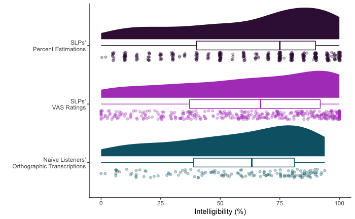

```r
# Saving Distribution plot

ggsave("Plots/Distribution_plot.png", plot = last_plot(),height = 5, width = 7, units = "in", scale = .8)
```

```r
# removing extra items from the environment

rm(intRatings_Long1, intRatings_Long2)
```

# Research Question #1

Q1: How reliable are these intelligibility measures (VAS ratings, approximations, and OT scores), as determined by intrarater and interrater agreement?

## Intrarater Reliability

### SLP VAS Ratings

```r
cor.test(slp_Correlation$slp_VAS, slp_Correlation$slp_VAS.Rel, method = "pearson", use = "complete.obs")
```

```
    Pearson's product-moment correlation

data:  slp_Correlation$slp_VAS and slp_Correlation$slp_VAS.Rel
t = 15.297, df = 75, p-value < 2.2e-16
alternative hypothesis: true correlation is not equal to 0
95 percent confidence interval:
 0.8026937 0.9157152
sample estimates:
     cor
0.870219
```

### SLP EST Ratings

```r
cor.test(slp_Correlation$slp_EST, slp_Correlation$slp_EST.Rel, method = "pearson", use = "complete.obs")
```

```
    Pearson's product-moment correlation

data:  slp_Correlation$slp_EST and slp_Correlation$slp_EST.Rel
t = 14.672, df = 82, p-value < 2.2e-16
alternative hypothesis: true correlation is not equal to 0
95 percent confidence interval:
 0.7786314 0.9009859
sample estimates:
      cor
0.8509701
```

## Interrater Reliability

### SLPs VAS rating

```r
slpVAS_Inter <- slp_Correlation %>%
  dplyr::select(!c(slp_VAS.Rel, slp_EST, slp_EST.Rel))

slpVAS_Inter_wide <- tidyr::pivot_wider(slpVAS_Inter, names_from = slpID, values_from = slp_VAS)

slpVAS_Inter_wide <- slpVAS_Inter_wide %>%
  dplyr::select(!Speaker)

k <- 1
while(k <= ncol(slpVAS_Inter_wide)){
  slpVAS_Inter_wide[is.na(slpVAS_Inter_wide[,k]), k] <- colMeans(slpVAS_Inter_wide[,k], na.rm = TRUE)
  k <- k + 1
}

irr::icc(slpVAS_Inter_wide, model = "twoway",
  type="agreement",
  unit="average", r0=0, conf.level=0.95)
```

```
 Average Score Intraclass Correlation

   Model: twoway
   Type : agreement

   Subjects = 20
     Raters = 21
  ICC(A,21) = 0.961

 F-Test, H0: r0 = 0 ; H1: r0 > 0
  F(19,132) = 37.6 , p = 5.35e-44

 95%-Confidence Interval for ICC Population Values:
  0.929 < ICC < 0.982
```

```r
irr::icc(slpVAS_Inter_wide, model = "twoway",
  type="agreement",
  unit="single", r0=0, conf.level=0.95)
```

```
 Single Score Intraclass Correlation

   Model: twoway
   Type : agreement

   Subjects = 20
     Raters = 21
   ICC(A,1) = 0.54

 F-Test, H0: r0 = 0 ; H1: r0 > 0
  F(19,138) = 37.6 , p = 4.83e-45

 95%-Confidence Interval for ICC Population Values:
  0.385 < ICC < 0.723
```

```r
# removing extra items from the environment

rm(slpVAS_Inter)
```

### SLPs Estimations

```r
slpEST_Inter <- slp_Correlation %>%
  dplyr::select(!c(slp_EST.Rel, slp_VAS, slp_VAS.Rel))

slpEST_Inter_wide <- tidyr::pivot_wider(slpEST_Inter, names_from = slpID, values_from = slp_EST)

slpEST_Inter_wide <- slpEST_Inter_wide %>%
  dplyr::select(!Speaker)

irr::icc(slpEST_Inter_wide, model = "twoway",
  type="agreement",
  unit="average", r0=0, conf.level=0.95)
```

```
 Average Score Intraclass Correlation

   Model: twoway
   Type : agreement

   Subjects = 20
     Raters = 21
  ICC(A,21) = 0.964

 F-Test, H0: r0 = 0 ; H1: r0 > 0
  F(19,156) = 39 , p = 2.31e-49

 95%-Confidence Interval for ICC Population Values:
  0.936 < ICC < 0.984
```

```r
irr::icc(slpEST_Inter_wide, model = "twoway",
  type="agreement",
  unit="single", r0=0, conf.level=0.95)
```

```
 Single Score Intraclass Correlation

   Model: twoway
   Type : agreement

   Subjects = 20
     Raters = 21
   ICC(A,1) = 0.563

 F-Test, H0: r0 = 0 ; H1: r0 > 0
  F(19,161) = 39 , p = 2.25e-50

 95%-Confidence Interval for ICC Population Values:
  0.41 < ICC < 0.74
```

```r
# removing extra items from the environment

rm(slpEST_Inter)
```

# Research Question #2

## Repeated Measures Correlation Analysis

Q2: Is there a strong relationship between SLP intelligibility percent estimates with SLP VAS intelligibility ratings?

```r
rmcorr::rmcorr(slpID, slp_VAS, slp_EST, slp_Correlation)
```

```
'slpID' coerced into a factor
```

```
Repeated measures correlation

r
0.6600224

degrees of freedom
381

p-value
2.90509e-49

95% confidence interval
0.5992933 0.7131983
```

## Scatterplot

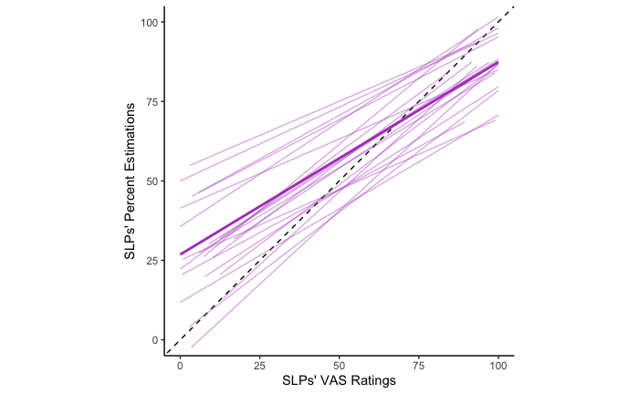

```r
slp_Correlation %>%
  ggplot() +
  aes(x = slp_VAS,
      y = slp_EST) +
  geom_abline(intercept = 0, slope = 1, linetype = 2) +
  geom_line(method = "lm", stat ="smooth", color = my_pal[2], aes(group = slpID), alpha = .4) +
  geom_smooth(method = "lm", se = F, color = my_pal[2]) +
  xlab("SLPs' VAS Ratings") +
  ylab("SLPs' Percent Estimations") +
  coord_cartesian(xlim = c(0, 100), ylim = c(0, 100)) +
  theme_classic() +
  theme(aspect.ratio = 1)

ggsave("Plots/RQ2_ScatterPlot.png", plot = last_plot(), height = 5, width = 5, units = "in", scale = .8)
```

# Research Question #3

Q1: Are SLP estimates of speech intelligibility predictive of naive listener estimations?

Since the speakers are the common variable between the SLP and Naive listener task, the mean SLP VAS rating, SLP estimation, and naive listener OT scores were calculated for each of the 20 speakers.

## Correlation Matrix

This first block explores the correlation matrix of SLP and Naive listener intelligibility ratings.

```r
# Correlation between Naive OT and SLP VAS
stats::cor.test(IntSpeakerRatings$slp_VAS, IntSpeakerRatings$naive_OT, method = "pearson", use = "complete.obs")
```

```
    Pearson's product-moment correlation

data:  IntSpeakerRatings$slp_VAS and IntSpeakerRatings$naive_OT
t = 7.6981, df = 18, p-value = 4.22e-07
alternative hypothesis: true correlation is not equal to 0
95 percent confidence interval:
 0.7074616 0.9500998
sample estimates:
      cor
0.8757991
```

```r
#Correlation between Naive OT and SLP percent estimations
stats::cor.test(IntSpeakerRatings$slp_EST, IntSpeakerRatings$naive_OT, method = "pearson", use = "complete.obs")
```

```
    Pearson's product-moment correlation

data:  IntSpeakerRatings$slp_EST and IntSpeakerRatings$naive_OT
t = 13.742, df = 18, p-value = 5.53e-11
alternative hypothesis: true correlation is not equal to 0
95 percent confidence interval:
 0.8887761 0.9825636
sample estimates:
      cor
0.9554978
```

```r
#Correlation between SLP VAS and SLP percent estimations
stats::cor.test(IntSpeakerRatings$slp_VAS, IntSpeakerRatings$slp_EST, method = "pearson", use = "complete.obs")
```

```
    Pearson's product-moment correlation

data:  IntSpeakerRatings$slp_VAS and IntSpeakerRatings$slp_EST
t = 9.0112, df = 18, p-value = 4.323e-08
alternative hypothesis: true correlation is not equal to 0
95 percent confidence interval:
 0.7708329 0.9620769
sample estimates:
      cor
0.9047387
```

## Modeling naive OT scores

### Modeling SLP estimation as predictor of naive listener OT.

```r
SLP_ESTmodel <- lm(naive_OT ~ slp_EST, data= IntSpeakerRatings)
summary(SLP_ESTmodel)
```

```
Call:
lm(formula = naive_OT ~ slp_EST, data = IntSpeakerRatings)

Residuals:
    Min      1Q  Median      3Q     Max
-9.4903 -4.8104 -0.5625  3.6255 10.4641

Coefficients:
            Estimate Std. Error t value Pr(>|t|)
(Intercept)  7.22884    4.02761   1.795   0.0895 .
slp_EST      0.81714    0.05946  13.742 5.53e-11 ***
---
Signif. codes:  0 ‘***’ 0.001 ‘**’ 0.01 ‘*’ 0.05 ‘.’ 0.1 ‘ ’ 1

Residual standard error: 5.86 on 18 degrees of freedom
Multiple R-squared:  0.913, Adjusted R-squared:  0.9081
F-statistic: 188.8 on 1 and 18 DF,  p-value: 5.53e-11
```

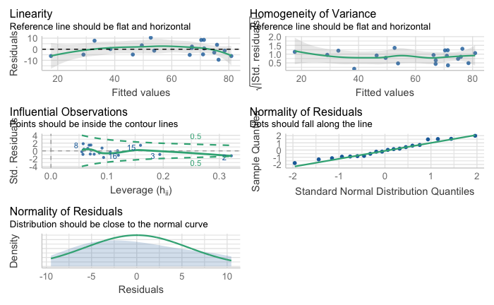

```r
performance::check_model(SLP_ESTmodel)
```

```r
sjPlot::tab_model(SLP_ESTmodel, file = "Tables/Estimation_model.html")
```

### Modeling SLP VAS as a predictor of naive listener OT.

```r
SLP_VASmodel <- lm(naive_OT ~ slp_VAS, data = IntSpeakerRatings)
summary(SLP_VASmodel)
```

```
Call:
lm(formula = naive_OT ~ slp_VAS, data = IntSpeakerRatings)

Residuals:
     Min       1Q   Median       3Q      Max
-13.7789  -8.5903   0.0229   5.4079  18.1889

Coefficients:
            Estimate Std. Error t value Pr(>|t|)
(Intercept) 17.12411    5.91533   2.895  0.00965 **
slp_VAS      0.68657    0.08919   7.698 4.22e-07 ***
---
Signif. codes:  0 ‘***’ 0.001 ‘**’ 0.01 ‘*’ 0.05 ‘.’ 0.1 ‘ ’ 1

Residual standard error: 9.588 on 18 degrees of freedom
Multiple R-squared:  0.767, Adjusted R-squared:  0.7541
F-statistic: 59.26 on 1 and 18 DF,  p-value: 4.22e-07
```

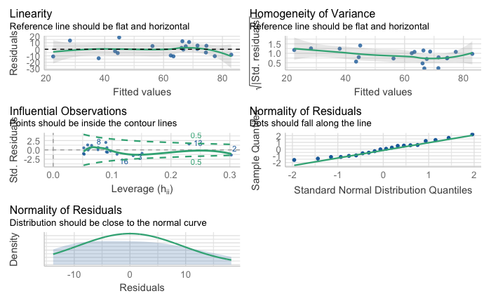

```r
performance::check_model(SLP_VASmodel)
```

```r
sjPlot::tab_model(SLP_VASmodel, file = "Tables/VAS_model.html")
```

## RQ3 Plot

```r
# creating long form data frame for plot

IntSpeakerRatings_Long <- IntSpeakerRatings %>%
  tidyr::pivot_longer(cols = slp_EST:slp_VAS, names_to = "Method",values_to = "rating") %>%
  dplyr::mutate(Method = recode(Method, slp_EST = "Percent Estimation", slp_VAS = "VAS Rating")) %>%
  dplyr::mutate(Method = as.factor(Method)) %>%
  dplyr::mutate(Method = fct_relevel(Method, "VAS Ratings", "Percent Estimations"))
```

```
Unknown levels in `f`: VAS Ratings, Percent Estimations
```

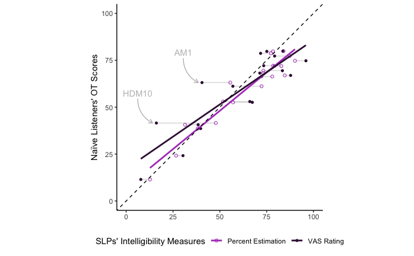

```r
# Creating RQ3 plot
arrows <- tibble(
  x1 = c(16.11100 - 10,40.47600 - 10),
  x2 = c(16.11100 - 2,40.47600 - 2),
  y1 = c(41.53846 + 13,63.10256 + 13),
  y2 = c(41.53846, 63.10256),
)
annotationColor <- "gray"
annotationAlpha <- 1

IntSpeakerRatings_Long %>%
  ggplot() +
  aes(x = rating,
      y = naive_OT,
      color = Method,
      shape = Method) +
  #adding data pairs and fitted regression line
  geom_line(inherit.aes = F,
            aes(x = rating,
                y = naive_OT,
                group = SpeakerID),
            color = "light gray",
            alpha = .8) +
  geom_point() +
  geom_smooth(method = "lm",
             se = F) +
  scale_color_manual(values = my_pal[2:3]) +
  scale_shape_manual(values = c(1, 16)) +
  #adding reference line to indicate theoretical perfict fit
  geom_abline(intercept = 0, slope = 1, linetype = 2) +
  ylab("Naïve Listeners' OT Scores") +
  labs(color = "SLPs' Intelligibility Measures", shape = "SLPs' Intelligibility Measures") +
  # Annotation for HDM1O & AM1
  geom_curve(inherit.aes = F,
    data = arrows, aes(x = x1, y = y1, xend = x2, yend = y2),
    arrow = arrow(length = unit(0.08, "inch")), size = 0.5,
    color = annotationColor,
    curvature = 0.3,
    alpha = annotationAlpha) +
  annotate("text",
           x = arrows$x1[1],
           y = arrows$y1[1] + 3,
           label = "HDM10",
           color = annotationColor,
           alpha = annotationAlpha) +
  annotate("text",
           x = arrows$x1[2],
           y = arrows$y1[2] + 3,
           label = "AM1",
           color = annotationColor,
           alpha = annotationAlpha) +
  #equalize the x and y axes
  coord_cartesian(xlim = c(0, 100), ylim = c(0, 100)) +
  theme_classic() +
  theme(legend.position = "bottom",
        axis.title.x=element_blank(),
        aspect.ratio = 1)

#Saving the scatterplot
ggsave("Plots/RQ3_ScatterPlot.png", plot = last_plot(), height = 5, width = 5, units = "in")
```

## SLP VAS x SLP EST Scatter

This is a scatterplot between SLP VAS and SLP estimations for the aggregate data

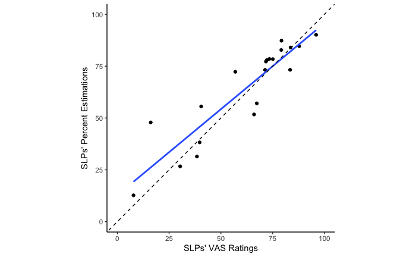

```r
IntSpeakerRatings %>%
  ggplot() +
  aes(x = slp_VAS,
      y = slp_EST) +
  #adding data pairs and fitted regression line
  geom_point() +
  geom_smooth(method = "lm",
              se = F) +
  #adding reference line to indicate theoretical perfict fit
  geom_abline(intercept = 0, slope = 1, linetype = 2) +
  ylab("SLPs' Percent Estimations") +
  xlab("SLPs' VAS Ratings") +
  scale_color_manual(values = my_pal[2:3]) +
  scale_shape_manual(values = c(1, 16)) +
  #equalize the x and y axes
  coord_cartesian(xlim = c(0, 100), ylim = c(0, 100)) +
  theme_classic() +
  theme(legend.position = "bottom",
        aspect.ratio = 1)
```

# Additional Analysis

## Relationship between Naïve OT scores and Naïve VAS Ratings of Intelligibility

### Repeated Measures Correlation

To test whether our results are consistent with previous research, we investigated the relationship between naïve OT scores and VAS ratings of intelligibility.

```r
rmcorr::rmcorr(ListenerID, naive_OT, naive_VAS, naive_Correlation)
```

```
'ListenerID' coerced into a factor
```

```
Repeated measures correlation

r
0.8882485

degrees of freedom
69

p-value
5.242799e-25

95% confidence interval
0.825011 0.9295159
```

### Scatterplot

To depict relationship between the two naïve listener intelligibility measures

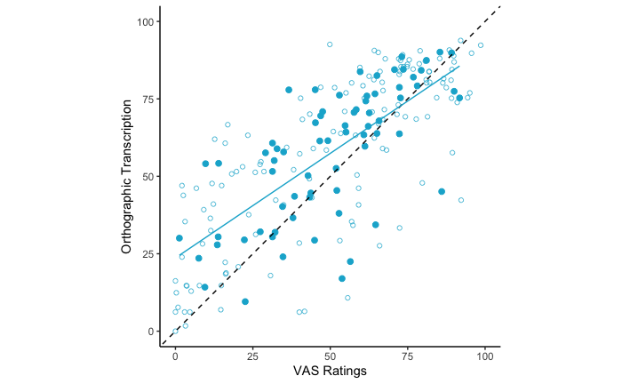

```r
naive_Correlation %>%
  ggplot() +
  aes(x = naive_VAS,
      y = naive_OT) +
  #Plotting all the raw VAS ratings and OT scores for every listener.
  #Listeners transcribed and rated 2 out of the 20 speakers, so every listener has 2 pairs of OT/VAS data.
  geom_point(color = my_pal[4], alpha = .7, shape = 1) +
  #Plotting the average OT score and VAS rating per Listener (i.e. the listener's mean OT score with the listener's mean VAS rating)
  geom_point(data = naive_Correlation %>%
               dplyr::group_by(ListenerID) %>%
               dplyr::summarize(naive_VAS = mean(naive_VAS),
                                naive_OT = mean(naive_OT)),
             color = my_pal[4], size = 2) +
  #Adding the reference line that indicates a theoretically perfect fit. Visualizes if VAS is under- or over-estimating OT scores.
  geom_abline(intercept = 0, slope = 1, linetype = 2) +
  geom_line(data = naive_Correlation %>%
               dplyr::group_by(ListenerID) %>%
               dplyr::summarize(naive_VAS = mean(naive_VAS),
                                naive_OT = mean(naive_OT)),
            method = "lm", stat = "smooth", se = F, color = my_pal[4]) +
  xlab("VAS Ratings") +
  ylab("Orthographic Transcription") +
  coord_cartesian(xlim = c(0,100), ylim = c(0, 100)) +
  theme_classic() +
  theme(aspect.ratio = 1)
```

## Modeling Naïve Listener VAS scores

### Examining SLP EST as a predictor of naive listener VAS.

```r
SLP_ESTmodel_VAS <- lm(naive_VAS ~ slp_EST, data = IntSpeakerRatings)
summary(SLP_ESTmodel_VAS)
```

```
Call:
lm(formula = naive_VAS ~ slp_EST, data = IntSpeakerRatings)

Residuals:
    Min      1Q  Median      3Q     Max
-23.100  -5.915   2.525   6.108  14.683

Coefficients:
            Estimate Std. Error t value Pr(>|t|)
(Intercept) -9.98814    6.63870  -1.505     0.15
slp_EST      0.97734    0.09801   9.972 9.33e-09 ***
---
Signif. codes:  0 ‘***’ 0.001 ‘**’ 0.01 ‘*’ 0.05 ‘.’ 0.1 ‘ ’ 1

Residual standard error: 9.659 on 18 degrees of freedom
Multiple R-squared:  0.8467,    Adjusted R-squared:  0.8382
F-statistic: 99.43 on 1 and 18 DF,  p-value: 9.331e-09
```

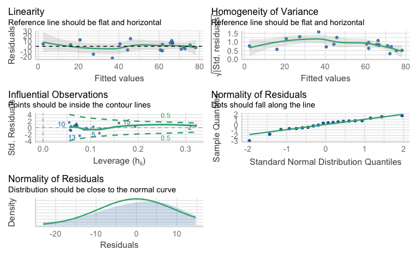

```r
performance::check_model(SLP_ESTmodel_VAS)
```

### Examining SLP VAS as a predictor of naive listener VAS.

```r
SLP_VASmodel_VAS <- lm(naive_VAS ~ slp_VAS, data = IntSpeakerRatings)
summary(SLP_VASmodel_VAS)
```

```
Call:
lm(formula = naive_VAS ~ slp_VAS, data = IntSpeakerRatings)

Residuals:
    Min      1Q  Median      3Q     Max
-20.550  -7.119   2.056   6.003  14.940

Coefficients:
            Estimate Std. Error t value Pr(>|t|)
(Intercept) -3.36401    5.59426  -0.601    0.555
slp_VAS      0.90548    0.08435  10.735 2.96e-09 ***
---
Signif. codes:  0 ‘***’ 0.001 ‘**’ 0.01 ‘*’ 0.05 ‘.’ 0.1 ‘ ’ 1

Residual standard error: 9.068 on 18 degrees of freedom
Multiple R-squared:  0.8649,    Adjusted R-squared:  0.8574
F-statistic: 115.2 on 1 and 18 DF,  p-value: 2.965e-09
```

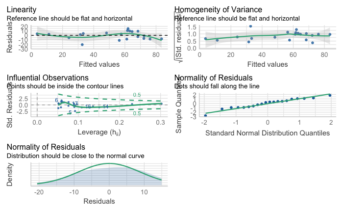

```r
performance::check_model(SLP_VASmodel_VAS)
```

# Supplementary Materials

## Table with All Speaker Means

```r
baseline_data <- rio::import("Shared Data/Speaker Baselines.xlsx")

slp_data <- slp_Correlation %>%
  dplyr::select(!c(slp_VAS.Rel, slp_EST.Rel)) %>%
  dplyr::group_by(Speaker) %>%
  dplyr::summarize(SLP_VAS = mean(slp_VAS, na.rm = T),
                   VAS_SD = sd(slp_VAS, na.rm = T),
                   SLP_EST = mean(slp_EST, na.rm = T),
                   EST_SD = sd(slp_EST, na.rm = T))

naive_data <- naive_Correlation %>%
  dplyr::select(!naive_VAS) %>%
  dplyr::group_by(SpeakerID) %>%
  dplyr::summarize(Naive_OT = mean(naive_OT, na.rm = T), Naive_SD = sd(naive_OT, na.rm = T)) %>%
  dplyr::rename(Speaker = SpeakerID)

Supp_Table <- dplyr::full_join(slp_data, naive_data, by = "Speaker") %>%
  dplyr::full_join(., baseline_data, by = "Speaker") %>%
  dplyr::relocate(Mean:SD, .before = SLP_VAS) %>%
  dplyr::filter(Speaker != "ALSF5")

Supp_Table %>%
  gt::gt() %>%
  gt::fmt_number(Mean:Naive_SD, decimals = 2) %>%
  gt::gtsave("Tables/Supp_Table.html")
```

## Figure

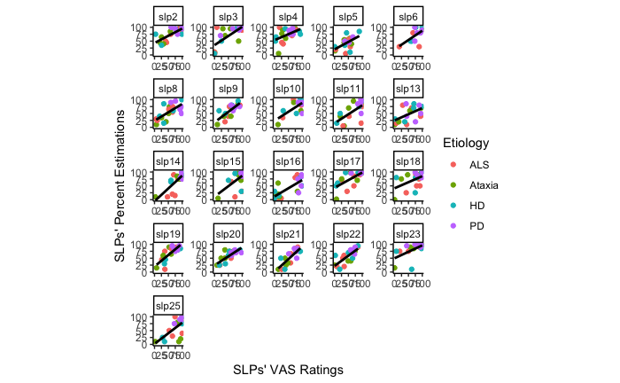

```r
slp_Correlation1 <- slp_Correlation %>%
  dplyr::mutate(slpID = factor(slpID, levels = c("slp2", "slp3", "slp4", "slp5", "slp6", "slp8", "slp9",
                                    "slp10", "slp11", "slp13", "slp14", "slp15", "slp16", "slp17", "slp18", "slp19",
                                    "slp20", "slp21", "slp22", "slp23", "slp25"))) %>%
  dplyr::mutate(Etiology = case_when(
    grepl("ALS", Speaker, fixed = T) ~ "ALS",
    grepl("PD", Speaker, fixed = T) ~ "PD",
    grepl("HD", Speaker, fixed = T) ~ "HD",
    TRUE ~ "Ataxia")) %>%
  dplyr::mutate(Etiology = as.factor(Etiology))

slp_Correlation1 %>%
  ggplot() +
  aes(x = slp_VAS,
      y = slp_EST) +
  geom_point(aes(color = Etiology)) +
  geom_smooth(method = "lm", se = F, color = "black") +
  coord_cartesian(xlim = c(0, 100), ylim = c(0, 100)) +
  facet_wrap("slpID", scales = "free") +
  xlab("SLPs' VAS Ratings") +
  ylab("SLPs' Percent Estimations") +
  theme_classic() +
  theme(aspect.ratio = 1)

ggsave("Plots/Supp_Scatterplot.png", plot = last_plot(), height = 5, width = 5, units = "in", scale = 1.5)
```